# Bootstrap Correlation

Andrew Engellant

02 February, 2024

## Introduction

In this assignment we explore how to test for significance when working with the correlation coefficient. We’ll calculate this statistic in a manual fashion (something you’d *never* do in real life). We’ll then use bootstrapping to estimate standard errors of the statistics. We’ll draw inference from those standard errors and compare the outcome to the tests we’re more familiar with. The data for this assignment is described in an appendix at the bottom of this document.

You might fairly ask why you need to calculate these statistics manually, when there are fast and reliable functions that will give you the same value in a fraction of the time. We’re mainly doing two things here: refreshing previous knowledge and learning the bootstrapping process. It’s easy to take a stats class that results in you vaguely knowing the $\chi^2$ statistic and correlation coefficient (symbolized by $\rho$). But writing the code from scratch usually locks in the ideas more firmly.

With regard to the bootstrap process, you’ll see that it’s not too critical here, since the standard approaches to this analysis give the same results. In most cases the traditional approaches to estimating these quantities (seen in `chisq.test` and `cor.test`) are fine. Here the bootstrap is like squirrel hunting with a bazooka. The power of the bootstrap is the ability to make good estimates of standard errors in situations where you have statistics that are *not* well behaved (or not well behaved with your population). See these statistics as a safe place to learn how to code up something like this. I’m also hopeful that you might be able to use a function like this in a case where the R function won’t work with your data for some reason.

There’s a secret third benefit as well. By writing code that matches the statistical software, you’re likely to trust your own abilities more. And the bootstrap method!

```r
d <- read_tsv(paste(here(),"survey_data.txt",sep="/"))
```

## Exploring the Data

The correlation coefficient, $\rho$, measures the linear association between two continuous variables. We can plot some of the numerical variables in our credit union data set using the handy “scatterplot matrix” functionality of the package `car` that accompanies the book “Companion to Applied Regression”. This function plots the distribution of the data on the diagonals. The off-diagonal panels show the scatterplot between the row variable and column variable. A smoothed curve and trendline are both fit as well.

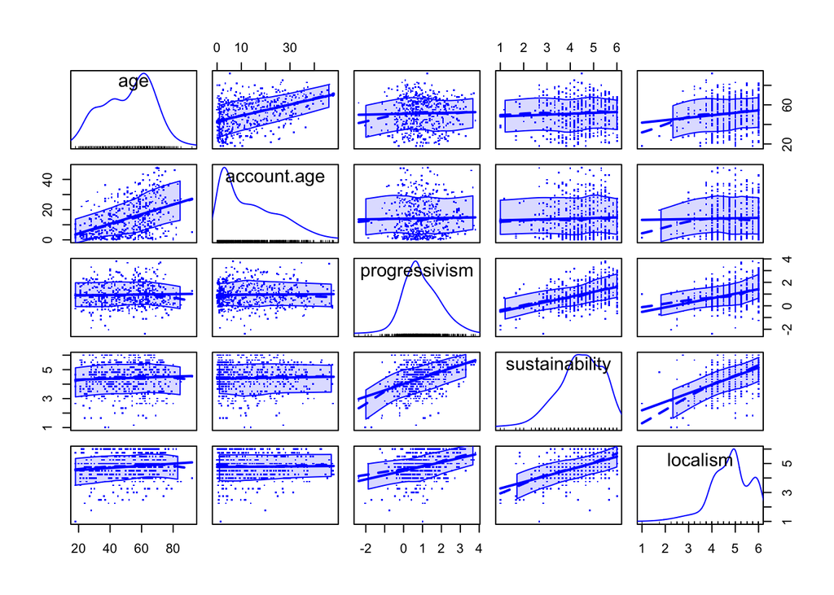

```r
d %>%
  slice_sample(prop=0.2) %>%
  select(age, account.age, progressivism, sustainability, localism) %>%
  car::spm(pch=".")
```

We are interested in the degree of linear association between the two variables. For instance, it appears there is a slight negative association between progressivism and age. There appears to be strong positive association between sustainability and localism.

To begin to get a sense of these data, let’s look at a simple measure of association (that, not coincidentally, is related to the mathematical definition of correlation). If two variables are correlated, than we would expect an above-mean value for one variable to be associated with an above-mean value for the other. In the code block below, calculate the following statistics:

1. What fraction of observations in `d` have above average values for both progessivism and age?
2. What fraction of observations in `d` have above average values for both sustainability and localism?
3. What fraction of observations in `d` have above average values for both sustainability and progressivism?

After you’ve calculated the statistics, write a bit about what you expect to happen when we use correlation coefficients to look at these relationships.

```r
#Your code goes here
#proportion of observations with above average progressivism and age
mean(d$progressivism > mean(d$progressivism) &
       d$age > mean(d$age))
```

```
## [1] 0.2399835
```

```r
#proportion of observations with above average sustainability and localism
mean(d$sustainability > mean(d$sustainability) &
       d$localism > mean(d$localism))
```

```
## [1] 0.4043784
```

```r
#proportion of observations with above average susainability and progressivism
mean(d$sustainability > mean(d$sustainability) &
       d$progressivism > mean(d$progressivism))
```

```
## [1] 0.3209418
```

I would expect the correlation coefficient to be furthest from zero when the proportion of observations with above average values in both variables is closest to 0.50. With this logic, I expect the coefficient for sustainability and localism to be greater than progressivism and age, and sustainability and progressivism.

## Correlation Coefficients

Recall that the definition of the correlation between $X$ and $Y$ (two random variables) is
$$\rho_{X,Y} = \frac{\textrm{cov}(X,Y)}{\sigma_X \cdot \sigma_Y}$$

We can further expand this by writing out the definitions for covariance and standard deviations:

$$\rho_{X,Y} = \frac{\textrm{cov}(X,Y)}{\sigma_X \cdot \sigma_Y} =
\frac{\sum(x_i - \bar{x})\cdot(y_i - \bar{y})}{\sqrt(
\sum(x_i-\bar{x})^2 \cdot \sum (y_i-\bar{y})^2)}$$

It may have been a while since you looked at this formula. Notice that the numerator is the product of the x values minus the mean of the x values times the y values minus their mean. Please answer this question as part of your assignment: When will the numerator of this fraction be large and when will it be small?

The numerator will be smallest when the relationship between the two variables is more linear. A more linear relationship causes the positive and negative residuals to balance out and sum closer to zero between the two varibales. As the data becomes more spread, a greater proportion of observations fall either above or below their means, leading to a larger numerator.

The denominator, which is the product of the standard deviations, functions as a normalizing term to ensure $-1 \leq \rho \leq 1$.

Now let’s build our own correlation coefficient. For the first step of our bootstrap work, write a function called `my.cor` that takes as input two vectors and returns the correlation coefficient between them. Verify that you get the same results as the `cor` function on the age and progressivism columns. Don’t use `sd` or `cov` or, obviously, `cor`.

```r
 # Finish your my.cor function here.

my.cor <- function(x,y){
  num <- sum((x - mean(x)) * (y - mean(y)))
  den <- sqrt(sum((x - mean(x))**2) * sum((y - mean(y))**2))
  return(num/den)
}

assert_that(abs(my.cor(d$age,d$progressivism)-cor(d$age,d$progressivism)) <= 0.0001)
```

```
## [1] TRUE
```

Now that we’ve written and verified our function, we can use this to analyze both the actual data set we have and a few thousand bootstrap replicates. The latter will tell us what the standard error *around* the correlation coefficient is likely to be. Let’s start with age and progressivism.

```r
# store the actual value in the data
measured.val <- my.cor(d$age,d$progressivism)

# the number of simulations to do
n.sim <- 1000
set.seed(314159) # ensures repeatable results.

# Create a data frame to hold our results.
results <- tibble(statistic=rep(NA,n.sim))
```

Now, write code that fills the `results` data frame with bootstrap replicates. So you’ll need to sample from `d` with replacement, then calculate the correlation coefficient of age and progressivism on this new data frame. Store those results by finishing the `for` loop, then I print out 10 random values for us. We’ll analyze and plot them down below.

```r
for(i in 1:n.sim){
  # Resample with replacement
  sim <- d[sample(nrow(d), replace = TRUE), ]
  #Store correlation coefficients in results tibble
  results$statistic[i] <- my.cor(sim$age,sim$progressivism)
}

# now let's look at 10 random values.
results %>%
  slice_sample(n=10) %>%
  t() %>%
  knitr::kable(digits=3)
```

| statistic | -0.034 | -0.027 | -0.031 | -0.06 | -0.07 | -0.042 | -0.051 | -0.058 | -0.053 | -0.064 |
| --- | --- | --- | --- | --- | --- | --- | --- | --- | --- | --- |

Bootstrap resampling gives us estimates of the variability around an estimate. We can use these replicates to get a confidence interval for our estimate of -0.042 using the quantile function. A 90% confidence interval ranges from -0.073 to -0.008. We can also plot the distribution of these values to understand the uncertainty in our estimate.

```r
pnorm(0, mean(results$statistic), sd(results$statistic))
```

```
## [1] 0.980026
```

```r
qnorm(.05, mean(results$statistic), sd(results$statistic))
```

```
## [1] -0.07522583
```

```r
quantile(results$statistic, p = .05)
```

```
##         5%
## -0.0730762
```

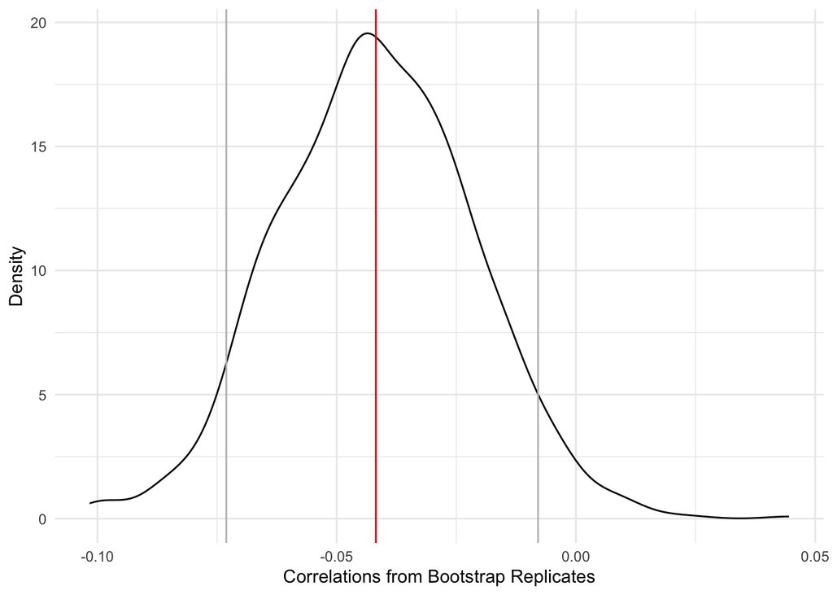

```r
ggplot(results,
       aes(x=statistic)) +
  geom_density() +
  theme_minimal() +
  # Add vertical lines with `geom_vline`
  geom_vline(xintercept = measured.val, color = "red") +
  geom_vline(xintercept = quantile(results$statistic, p = .05), color = "grey") +
  geom_vline(xintercept = quantile(results$statistic, p = .95), color = "grey") +
  labs(x="Correlations from Bootstrap Replicates",
       y="Density")
```

```r
#Can we find the percentage of the distribution results below 0 to directly state our confidence that the correlation coefficient is below 0?
pnorm(0, mean(results$statistic), sd(results$statistic))
```

```
## [1] 0.980026
```

```r
mean(results$statistic < 0)
```

```
## [1] 0.982
```

```r
#Can we be 100% confident the correlation is not 0? The odds of the true correlation coefficient being exactly zero seems nearly impossible.
mean(results$statistic != 0)
```

```
## [1] 1
```

Add a red vertical line for `measured.val` and two gray vertical lines for the 5th and 95th percentiles of the distribution. Write a little bit about what we can infer from the plot. Is the correlation likely to positive or negative? How confident are we that the correlation is not zero?

We can use base R’s `cor.test` function as a comparison.

```r
cor.test(d$progressivism,d$age,conf.level = 0.9)
```

```
##
##  Pearson's product-moment correlation
##
## data:  d$progressivism and d$age
## t = -2.0583, df = 2419, p-value = 0.03967
## alternative hypothesis: true correlation is not equal to 0
## 90 percent confidence interval:
##  -0.07514579 -0.00838706
## sample estimates:
##         cor
## -0.04181309
```

The correlation test resulted in a correlation coefficient of -0.0418 which indicated progressiveness and age are weakly negatively correlated. This matches the correlation coefficient we previously calculated. The 90% confidence interval resulted in a range from -0.0751 and -0.0084. These values are very close to the ones calculated in our bootstrap simulation. If we increase the number of simulations from 1000 to 10000 or 100000 our calculated confidence interval would likely match the cor.test results with higher precision.

Now repeat the above analyses for our other two correlations, sustainability versus localism and sustainability versus progressivism. Repeat the process from above, doing bootstrap replicates, calculating confidence intervals, plotting the results, and interpreting them. As above, compare your results to `cor.test`.

### Additional Correlations

##Sustainability and Localism Correlation

```r
# store the actual value in the data
measured.val <- my.cor(d$sustainability,d$localism)

# the number of simulations to do
n.sim <- 1000
set.seed(314159) # ensures repeatable results.

# Create a data frame to hold our results.
results <- tibble(statistic=rep(NA,n.sim))

#Bootstrap Resample
for(i in 1:n.sim){
  sim <- d[sample(nrow(d), replace = TRUE), ]
  results$statistic[i] <- my.cor(sim$sustainability,sim$localism)
}

# now let's look at 10 random values.
results %>%
  slice_sample(n=10) %>%
  t() %>%
  knitr::kable(digits=3)
```

| statistic | 0.475 | 0.495 | 0.499 | 0.501 | 0.448 | 0.524 | 0.474 | 0.49 | 0.519 | 0.512 |
| --- | --- | --- | --- | --- | --- | --- | --- | --- | --- | --- |

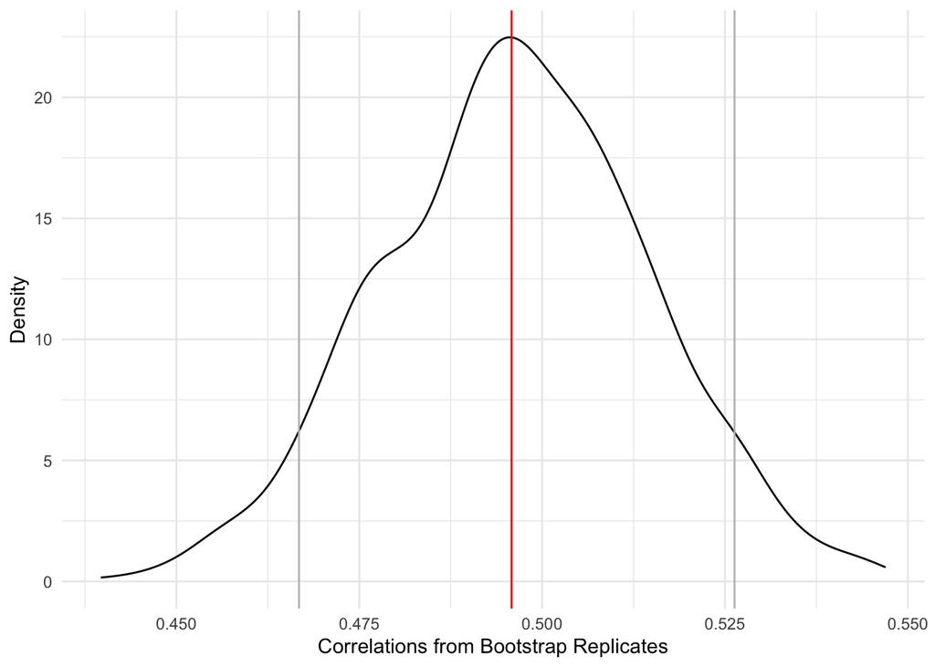

```r
ggplot(results,
       aes(x=statistic)) +
  geom_density() +
  theme_minimal() +
  # Add vertical lines with `geom_vline`
  geom_vline(xintercept = measured.val, color = "red") +
  geom_vline(xintercept = quantile(results$statistic, p = .05), color = "grey") +
  geom_vline(xintercept = quantile(results$statistic, p = .95), color = "grey") +
  labs(x="Correlations from Bootstrap Replicates",
       y="Density")
```

```r
quantile(results$statistic, p = .05)
```

```
##        5%
## 0.4667602
```

```r
quantile(results$statistic, p = .95)
```

```
##       95%
## 0.5263124
```

```r
cor.test(d$sustainability, d$localism, conf.level = 0.9)
```

```
##
##  Pearson's product-moment correlation
##
## data:  d$sustainability and d$localism
## t = 28.081, df = 2419, p-value < 2.2e-16
## alternative hypothesis: true correlation is not equal to 0
## 90 percent confidence interval:
##  0.4701759 0.5206249
## sample estimates:
##       cor
## 0.4958186
```

The correlation coefficient from the sampled data for sustainability and localism is 0.496 indicating a moderate positive correlation between the two variables. We have 90% confidence that the actual correlation for these two variable is between 0.467 and 0.526. This confidence interval is very close to the values produced by the cor.test function, which give a 90% confidence interval of 0.470 to 0.521.

##Sustainability and Progressivism Correlation

```r
# store the actual value in the data
measured.val <- my.cor(d$sustainability,d$progressivism)

# the number of simulations to do
n.sim <- 1000
set.seed(314159) # ensures repeatable results.

# Create a data frame to hold our results.
results <- tibble(statistic=rep(NA,n.sim))

#Bootstrap Resample
for(i in 1:n.sim){
  sim <- d[sample(nrow(d), replace = TRUE), ]
  results$statistic[i] <- my.cor(sim$sustainability,sim$progressivism)
}

# now let's look at 10 random values.
results %>%
  slice_sample(n=10) %>%
  t() %>%
  knitr::kable(digits=3)
```

| statistic | 0.382 | 0.333 | 0.352 | 0.366 | 0.353 | 0.362 | 0.37 | 0.382 | 0.375 | 0.371 |
| --- | --- | --- | --- | --- | --- | --- | --- | --- | --- | --- |

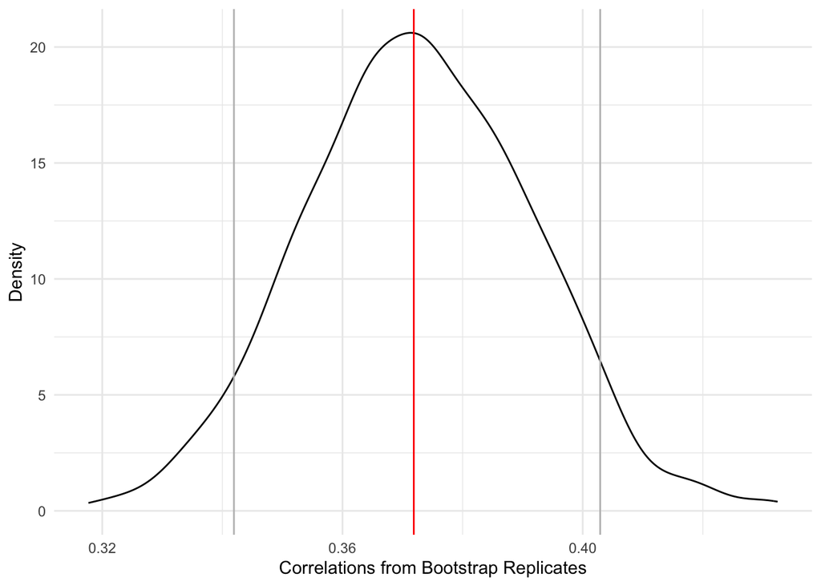

```r
ggplot(results,
       aes(x=statistic)) +
  geom_density() +
  theme_minimal() +
  # Add vertical lines with `geom_vline`
  geom_vline(xintercept = measured.val, color = "red") +
  geom_vline(xintercept = quantile(results$statistic, p = .05), color = "grey") +
  geom_vline(xintercept = quantile(results$statistic, p = .95), color = "grey") +
  labs(x="Correlations from Bootstrap Replicates",
       y="Density")
```

```r
quantile(results$statistic, p = .05)
```

```
##        5%
## 0.3419274
```

```r
quantile(results$statistic, p = .95)
```

```
##       95%
## 0.4029066
```

```r
cor.test(d$sustainability, d$progressivism, conf.level = 0.9)
```

```
##
##  Pearson's product-moment correlation
##
## data:  d$sustainability and d$progressivism
## t = 19.703, df = 2419, p-value < 2.2e-16
## alternative hypothesis: true correlation is not equal to 0
## 90 percent confidence interval:
##  0.3426930 0.4003294
## sample estimates:
##       cor
## 0.3718695
```

The correlation coefficient from the sampled data for sustainability and progressivism is 0.372 indicating a moderate positive correlation between the two variables. We have 90% confidence that the actual correlation for these two variable is between 0.342 and 0.403. This confidence interval is very close to the values produced by the cor.test function, which give a 90% confidence interval of 0.342 to 0.400.

## Appendix: Full Data Description

A financial institution in Washington has become concerned that their current membership base is not well-aligned with their corporate values. Through that concern they realized that don’t actually understand their membership’s values very well. They surveyed 2,421 members to shed light on the issue.

The heart of the survey was the Moral Foundations Theory of Jonathan Haidt. Members were surveyed on the Moral Foundations Questionnaire, which you should take so you understand the test. Survey respondents were scored on the five foundations as well as a single-number summary, Progressivism.

The financial institution values Localism, Sustainability, and Education. These aspects of member’s values were assessed in the survey as well. Localism and Sustainability used validated scales and thus can be summarized via a single score, where higher values indicate greater support for the values. Education is summarized by the following three questions, which we do not have evidence can be combined into a single score:

- In general, public schools provide a better education than private schools.
- Public school teachers are underpaid.
- Experience is more important than education in determining success in life. These questions were evaluated on a 1 to 6 scale where 1 indicated “Strongly Disagree” and 6 indicated “Strongly Agree”.

Finally, we have information on the member that can be used to understand variation in their values.

The data consists of the following columns: